# HW08 Clustering

Kuei Yueh Ko

2017/4/18

# Set Environment

import necessary library

```r
#library(dyplyr)
#library(tidyr)
#library(ggplot2)
library(vegan)
library(cluster)
library(fpc)
library(proxy)
```

setting directories

```r
workdir <- "C:\\Users\\clint\\Documents\\GitHub\\BlogDataAnalysis"
setwd(workdir)

filePathData <- file.path(
    workdir,
    "Data/StatCompEcology/Copepod")
```

import data

```r
# intialize a list to store data
datCPOD <- list()

# read tables
dat <- read.table(file.path(
    filePathData, "cop_density.txt"),
    header=T)
datCPOD$Density <- dat

dat <- read.table(file.path(
    filePathData, "copepod_composition.txt"),
    header=T)
datCPOD$Compose <- dat

dat <- read.table(file.path(
    filePathData, "copepodSPlist.txt"),
    sep="\t", header=F)
datCPOD$SP_Total <- as.character(dat$V1)

# Search for dominant species
dat <- datCPOD$Compose
temp <- apply(dat >= 2, 1, sum)
datCPOD$SP_Dominant <- which(temp > 0)

# Extract the composition of dominant species
dat <- datCPOD$Compose
idx <- datCPOD$SP_Dominant
idn <- datCPOD$SP_Total
dat <- dat[idx,]
rownames(dat) <- idn[idx]

# composition of dominant species
# Note: transform the matrix since
# we are clustering on stations
datCPOD$CompDmt <- t(dat)
datCPOD$CompDmtScale <- scale(t(dat)) # scales the columns of a numeric matrix
#head(datCPOD$CompDmtScale)
```

The goal is to perform cluster analysis of **stations** based on percent composition data of the dominant. Below is the boxplot summarize the dataset.

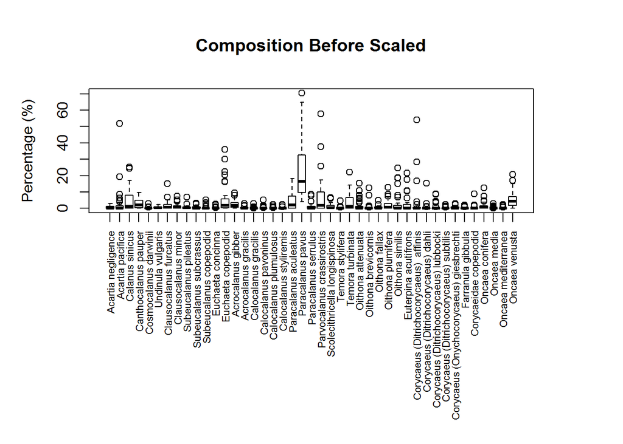

```r
# set plot
par(mfrow=c(1,1))
par(mar = c(13,5,5,5))

#
dat <- datCPOD$CompDmt
boxplot(dat,
        xaxt= "n",
        #xlab="Species",
        ylab="Percentage (%)",
        main="Composition Before Scaled")
axis(1, at=seq_len(ncol(dat)),
     labels=colnames(dat),
     las=2, cex.axis=0.7)
```

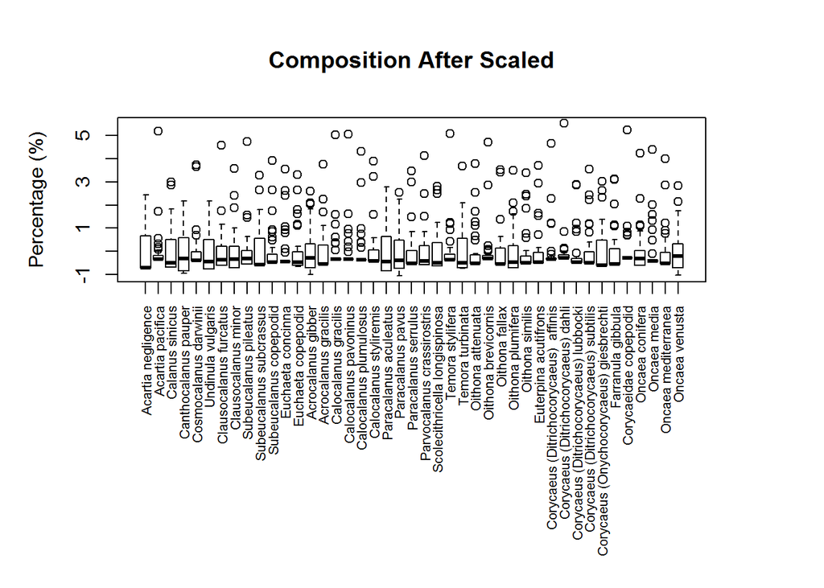

```r
dat <- datCPOD$CompDmtScale
boxplot(dat,
        xaxt= "n",
        #xlab="Species",
        ylab="Percentage (%)",
        main="Composition After Scaled")
axis(1, at=seq_len(ncol(dat)),
     labels=colnames(dat),
     las=2, cex.axis=0.7)
```

```r
# reset plot
par(mfrow=c(1,1))
par(mar = c(6,5,2,6))
```

here I test data

```r
dat = read.table(
    file.path(
        filePathData,
        'enviANDdensity.txt'),
    header=T)

# Stored the raw table in a list
envdata = list()
envdata$Raw = dat

# standardize data
# (Remove first line: Station)
envdata$Scale = scale(dat[,-1])
```

# Different Distance methods

Built-in distance methods in R

```r
#compute distance matrix
#dist.eucl = dist(data.std,method='euclidean')
#lstOfDist = list()
#lstofDist$Eucl = dist(data.std,method='euclidean')
#lstofDist$max = dist(data.std,method='maximum')
#lstofDist$man = dist(data.std,method='manhattan')
#lstofDist$cam = dist(data.std,method='camberra')
#lstofDist$bin = dist(data.std,method='binary')
#lstofDist$Mski = dist(data.std,method='minkowski')
```

Adopt distance more methods from library proxy

```r
summary(pr_DB)
```

```
## * Similarity measures:
## Braun-Blanquet, Chi-squared, correlation, cosine, Cramer, Dice,
## eDice, eJaccard, Fager, Faith, Gower, Hamman, Jaccard,
## Kulczynski1, Kulczynski2, Michael, Mountford, Mozley, Ochiai,
## Pearson, Phi, Phi-squared, Russel, simple matching, Simpson,
## Stiles, Tanimoto, Tschuprow, Yule, Yule2
##
## * Distance measures:
## Bhjattacharyya, Bray, Canberra, Chord, divergence, Euclidean,
## fJaccard, Geodesic, Hellinger, Kullback, Levenshtein, Mahalanobis,
## Manhattan, Minkowski, Podani, Soergel, supremum, Wave, Whittaker
```

- Similarity measures: Braun-Blanquet, Chi-squared, correlation, cosine, Cramer, Dice, eDice, eJaccard, Fager, Faith, Gower, Hamman, Jaccard, Kulczynski1, Kulczynski2, Michael, Mountford, Mozley, Ochiai, Pearson, Phi, Phi-squared, Russel, simple matching, Simpson, Stiles, Tanimoto, Tschuprow, Yule, Yule2
- Distance measures: Bhjattacharyya, Bray, Canberra, Chord, divergence, Euclidean, fJaccard, Geodesic, Hellinger, Kullback, Levenshtein, Mahalanobis, Manhattan, Minkowski, Podani, Soergel, supremum, Wave, Whittaker

Get distance matrix from dissimilarity

```r
lstOfDist <- list()
lstOfDist$MethodType <- c(
    'Euclidean','Maximum',
    'Manhattan','Canberra',
    #'Mahalanobis',
    'Chord')

# real value
#dat <- envdata$Scale
dat <- datCPOD$CompDmtScale
lstOfDist$Euclidean   = dist(dat ,method='Euclidean')
lstOfDist$Maximum     = dist(dat ,method='maximum')
lstOfDist$Manhattan   = dist(dat ,method='manhattan')
lstOfDist$Canberra    = dist(dat ,method='canberra')
#lstOfDist$Mahalanobis = dist(dat, method='Mahalanobis')
#   Error in solve.default(cov, ...) :
#       system is computationally singular
lstOfDist$Chord       = dist(dat, method='Chord')
```

# Determine number of clusters

I have found three ways to determine the number clusters

```r
#par(mfrow=c(1,1))
par(mar = c(4,4,4,4))
```

### First Method: sum of squares within cluster

The first method is to calculate the add up the sum of squares within each cluster. The analyst looks for a bend in the plot similar to a scree test in factor analysis. See Everitt & Hothorn (pg. 251).

For more information;

- http://www.statmethods.net/advstats/cluster.html
- http://stackoverflow.com/questions/15376075/cluster-analysis-in-r-determine-the-optimal-number-of-clusters

```r
#dat <- envdata$Scale
dat <- datCPOD$CompDmtScale

# Determine number of clusters
wss <- (nrow(dat)-1)*sum(apply(dat,2,var))
for (i in 2:15){
    wss[i] <- sum(kmeans(dat, centers=i)$withinss)
} # end for loop
```

To help us finding the elbows, we can compute discrete derivative from the input sequence

```r
seqDiff <- function(x){
    res <- x[-1] - x[-length(x)]
    return(res)
} # end function seqDiff
```

Here I plot two lines with different axies. For information, look up the website: https://www.r-bloggers.com/r-single-plot-with-two-different-y-axes/

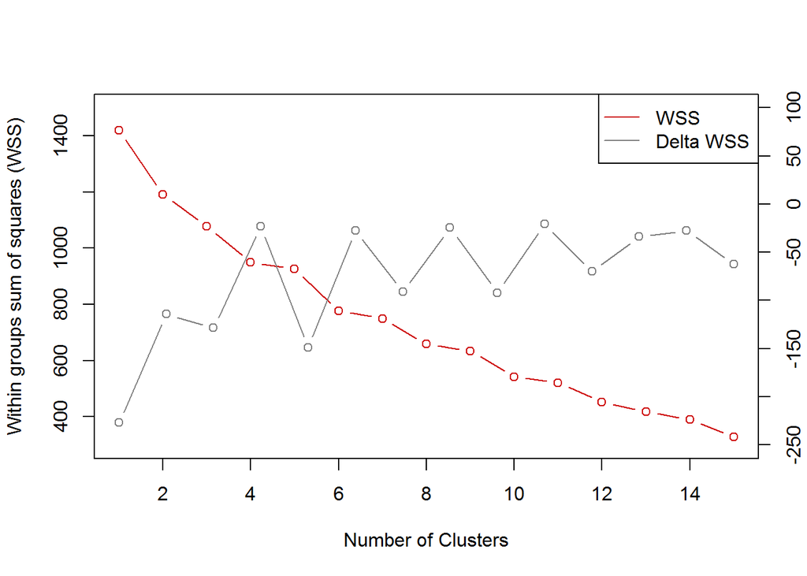

```r
# First plot
plot(1:15, wss, type="b", col="red3",
     xlab="Number of Clusters",
     ylab="Within groups sum of squares (WSS)",
     ylim=c(300,1500))

# second plot
par(new = T)
plot(1:14, seqDiff(wss), type="b", col="grey50",
     axes=F, xlab=NA, ylab=NA,
     ylim=c(-250,100))

# update the axis of second plot
axis(side = 4)
mtext(side = 4, line = 3, cex=1.0, 'Delta WSS')

# add legend
legend("topright",
       legend=c("WSS", "Delta WSS"),
       lty=c(1,1), pch=c(NA, NA),
       col=c("red3", "grey50"))
```

From the plot, the best number of clusters might be around 5 and 6. Here I choose k=5.

### Second Method:Silhouette

The Silhouette scores are calculated by comparing distances within and among clusters.

Since we need to perform clustering first to calculate Silhouette scores, we need to choose the distance matrix

```r
numSil <- list()
kbest  <- c()

# calculate the Silhouette scores for each distance matrix
for (idx in lstOfDist$MethodType){

    # initialize a vector
    print(idx)
    numSil[[idx]] <- numeric(15)
    matDist <- lstOfDist[[idx]]

    # calculate Silhouette scores
    for (k in 2:15){
        # average of Silhouette scores
        numSil[[idx]][k] <- pam(matDist, k)$silinfo$avg.width
    } # end inner for loop

    kbest <- c(kbest, which.max(numSil[[idx]]))
} # end outer for loop
```

```
## [1] "Euclidean"
## [1] "Maximum"
## [1] "Manhattan"
## [1] "Canberra"
## [1] "Chord"
```

```r
names(kbest) <- lstOfDist$MethodType
```

plot the result

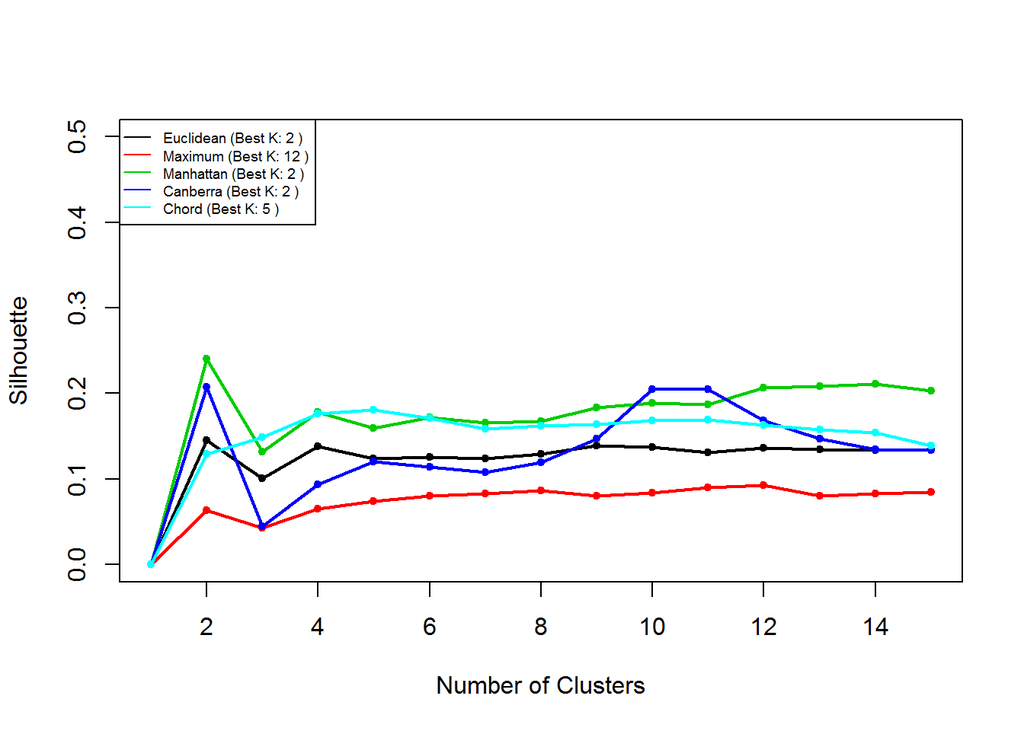

```r
library(RColorBrewer)
n = length(lstOfDist$MethodType)
cols = palette(rainbow(n))

plot(numSil$Euclidean, type='l',
     xlab="Number of Clusters",
     ylab="Silhouette",
     #xlim=c(0, 10),
     ylim=c(0, 0.5))

for (idx in seq_len(n)){
    vec = numSil[[idx]]
    lines( vec, col=cols[idx], lwd=2)
    points(vec, col=cols[idx], pch=20, cex=1)
}

# add legend
legend("topleft",
       legend=paste(lstOfDist$MethodType, "(Best K:", kbest, ")"),
       lty=1, pch=NA, cex=0.6, col=cols)
```

Silhouette Score(https://www.stat.berkeley.edu/~s133/Cluster2a.html)

| Range of SC | Interpretation |
| --- | --- |
| 0.71-1.0 | A strong structure has been found |
| 0.51-0.70 | A reasonable structure has been found |
| 0.26-0.50 | The structure is weak and could be artificial |
| < 0.25 | No substantial structure has been found |

It is interesting that different distance method result in different number of clusters. The number of k is 5 using Chord distance matrix and 12 using maximum distance matrix. The number is 2 for other matrix

### Third Method: Calinsky criterion

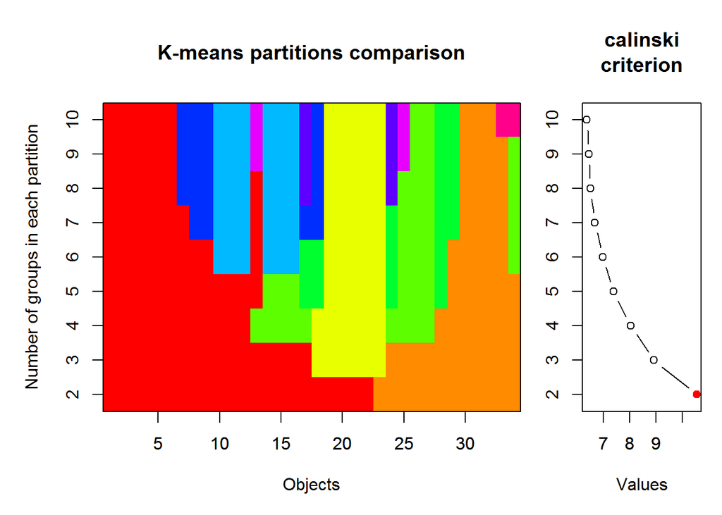

```r
# here we choose Euclean distance for our distance method
matDist = lstOfDist$Euclidean

# Calculate Calinsky criterion
require(vegan)
fit <- cascadeKM(
    scale(matDist, center = TRUE,  scale = TRUE),
    1, 10, iter = 1000)

# plot the result
plot(fit, sortg = TRUE, grpmts.plot = TRUE)
```

```r
# show the best number of cluster
calinski.best <- as.numeric(which.max(fit$results[2,]))
cat("Calinski criterion optimal number of clusters:", calinski.best, "\n")
```

```
## Calinski criterion optimal number of clusters: 2
```

The third method report that the best number of cluster is 2.

# Compute k-means NHC

recall the number of clusters for different distance matrices

```r
# result from Silhouette Scores
print(kbest)
```

```
## Euclidean   Maximum Manhattan  Canberra     Chord
##         2        12         2         2         5
```

perform Kmeans clustering

```r
# initialization
dat = datCPOD$CompDmtScale
lstOfKClust <- list()

# kmeans
for (idx in lstOfDist$MethodType){
    k = kbest[idx]
    matDist = lstOfDist[[idx]]
    lstOfKClust[[idx]] <- pam(matDist,k=k)
    #lstOfKClust[[idx]] <- clara(dat , k=k)
    # Note:
    # Compared to other partitioning methods such as pam,
    # clara can deal with much larger datasets. Each sub-
    # dataset is partitioned into k clusters using the same
    # algorithm as in pam.
} # end for loop
```

### Bootstrap Stability Analysis

For more information:  
- bootstrap evaluation of clusters  
- https://www.r-bloggers.com/bootstrap-evaluation-of-clusters/ - Practical Data Science with R - https://www.manning.com/books/practical-data-science-with-r

```r
# initialization
dat <- datCPOD$CompDmtScale
lstOfKCBoot <- list()

# evaluate cluster stability
for (idx in lstOfDist$MethodType){
    k = kbest[idx]
    matDist = lstOfDist[[idx]]
    lstOfKCBoot[[idx]] = clusterboot(
        dat, B=100,
        metric=idx, ## IMPORTANT
        bootmethod=c('boot','subset'),
        clustermethod=claraCBI,
        usepam=TRUE,
        k=k,        ## IMPORTANT
        count=FALSE)
} # end for loop
```

### Cluster around 2 mediods (clusters)

*Euclidean Distance Method*

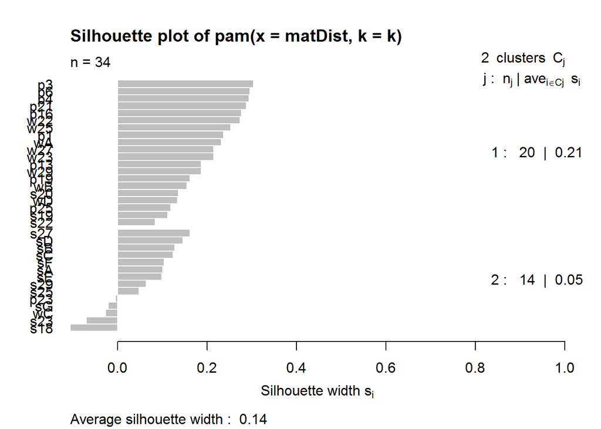

```r
plot(lstOfKClust$Euclidean)
```

```r
print(lstOfKCBoot$Euclidean)
```

```
## * Cluster stability assessment *
## Cluster method:  clara/pam
## Full clustering results are given as parameter result
## of the clusterboot object, which also provides further statistics
## of the resampling results.
## Number of resampling runs:  100
##
## Number of clusters found in data:  2
##
##  Clusterwise Jaccard bootstrap (omitting multiple points) mean:
## [1] 0.8566429 0.8277949
## dissolved:
## [1]  8 12
## recovered:
## [1] 82 77
##  Clusterwise Jaccard subsetting mean:
## [1] 0.8236874 0.7704751
## dissolved:
## [1] 12 18
## recovered:
## [1] 73 63
```

```r
#Clusterwise Jaccard bootstrap (omitting multiple points) mean:
#[1] 0.8560952 0.8204726
```

*Manhattan Distance Method*

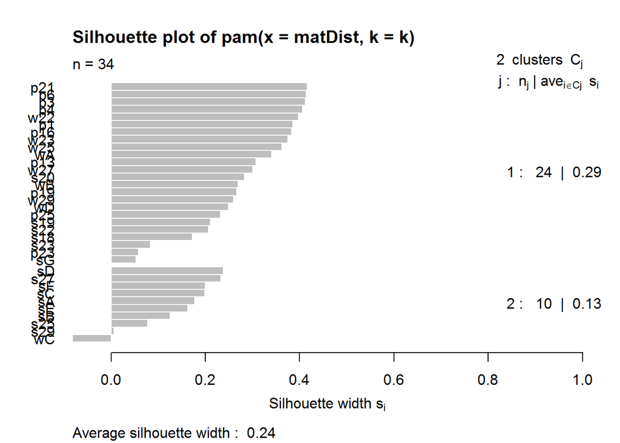

```r
plot(lstOfKClust$Manhattan)
```

```r
print(lstOfKCBoot$Manhattan)
```

```
## * Cluster stability assessment *
## Cluster method:  clara/pam
## Full clustering results are given as parameter result
## of the clusterboot object, which also provides further statistics
## of the resampling results.
## Number of resampling runs:  100
##
## Number of clusters found in data:  2
##
##  Clusterwise Jaccard bootstrap (omitting multiple points) mean:
## [1] 0.8580819 0.8280949
## dissolved:
## [1]  7 11
## recovered:
## [1] 82 76
##  Clusterwise Jaccard subsetting mean:
## [1] 0.8062182 0.7715599
## dissolved:
## [1] 15 18
## recovered:
## [1] 66 56
```

```r
#Clusterwise Jaccard bootstrap (omitting multiple points) mean:
#[1] 0.8899740 0.8697414
```

*Canderra Distance Method*

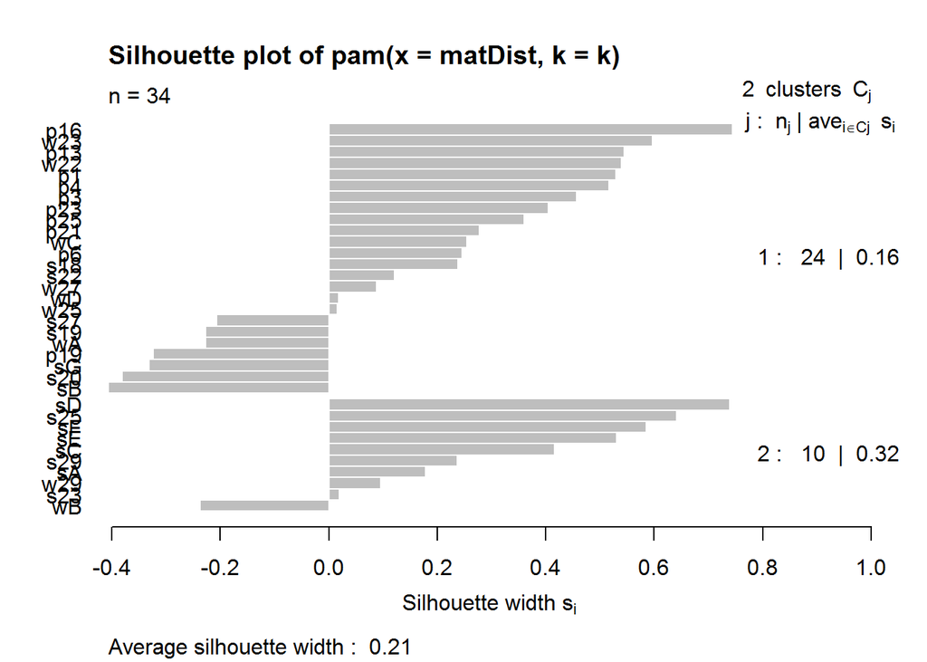

```r
plot(lstOfKClust$Canberra)
```

```r
print(lstOfKCBoot$Canberra)
```

```
## * Cluster stability assessment *
## Cluster method:  clara/pam
## Full clustering results are given as parameter result
## of the clusterboot object, which also provides further statistics
## of the resampling results.
## Number of resampling runs:  100
##
## Number of clusters found in data:  2
##
##  Clusterwise Jaccard bootstrap (omitting multiple points) mean:
## [1] 0.8840228 0.8616320
## dissolved:
## [1] 6 6
## recovered:
## [1] 88 83
##  Clusterwise Jaccard subsetting mean:
## [1] 0.8027093 0.7603614
## dissolved:
## [1] 11 20
## recovered:
## [1] 65 64
```

```r
#Clusterwise Jaccard bootstrap (omitting multiple points) mean:
#[1] 0.853512 0.827116
```

### Cluster around 5 mediods (clusters)

*Chord Distance Method*

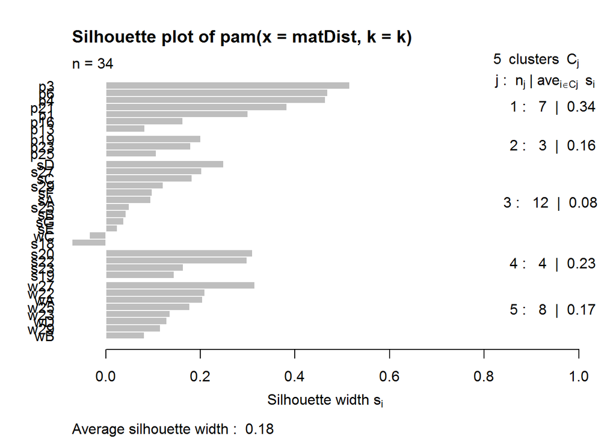

```r
plot(lstOfKClust$Chord)
```

```r
print(lstOfKCBoot$Chord)
```

```
## * Cluster stability assessment *
## Cluster method:  clara/pam
## Full clustering results are given as parameter result
## of the clusterboot object, which also provides further statistics
## of the resampling results.
## Number of resampling runs:  100
##
## Number of clusters found in data:  5
##
##  Clusterwise Jaccard bootstrap (omitting multiple points) mean:
## [1] 0.7043896 0.4797691 0.7908006 0.6028373 0.7310097
## dissolved:
## [1] 23 66 12 51 21
## recovered:
## [1] 42 19 70 38 45
##  Clusterwise Jaccard subsetting mean:
## [1] 0.5936825 0.4376569 0.7040444 0.4128889 0.6556548
## dissolved:
## [1] 51 80 18 73 37
## recovered:
## [1] 29  9 42 21 39
```

```r
#Clusterwise Jaccard bootstrap (omitting multiple points) mean:
#[1] 0.6657579 0.4551443 0.8271187 0.6194841 0.7242302
```

### Cluster around 12 mediods (clusters)

*Maximum Distance Method*

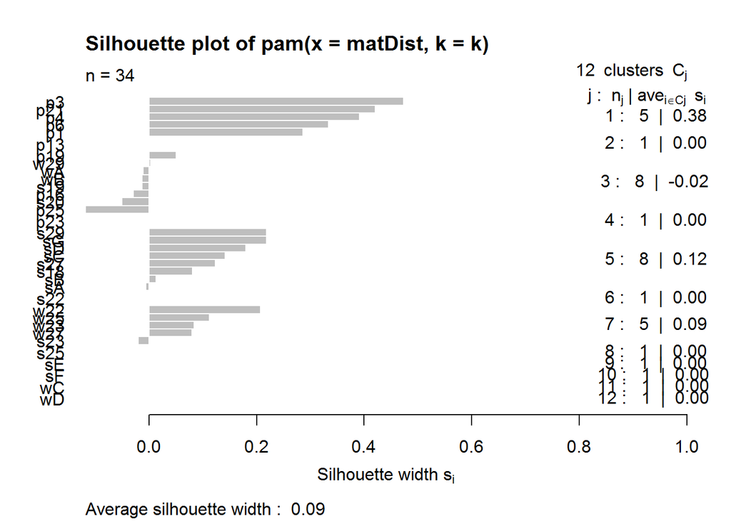

```r
plot(lstOfKClust$Maximum)
```

```r
print(lstOfKCBoot$Maximum)
```

```
## * Cluster stability assessment *
## Cluster method:  clara/pam
## Full clustering results are given as parameter result
## of the clusterboot object, which also provides further statistics
## of the resampling results.
## Number of resampling runs:  100
##
## Number of clusters found in data:  12
##
##  Clusterwise Jaccard bootstrap (omitting multiple points) mean:
##  [1] 0.7574048 0.4461071 0.6420000 0.5681429 0.8433333 0.6500000 0.6400000
##  [8] 0.6400000 0.7573333 0.5733333 0.6500000 0.6500000
## dissolved:
##  [1] 19 73 36 47 22 35 36 36 18 44 35 35
## recovered:
##  [1] 47 10 64  9 68 65 64 64 39 56 65 65
##  Clusterwise Jaccard subsetting mean:
##  [1] 0.7548333 0.4560595 0.5800000 0.4654762 0.7283333 0.4800000 0.4200000
##  [8] 0.5100000 0.7056667 0.5800000 0.4600000 0.4600000
## dissolved:
##  [1] 23 84 42 76 34 52 58 49 37 42 54 54
## recovered:
##  [1] 49  9 58  6 58 48 42 51 37 58 46 46
```

```r
#Clusterwise Jaccard bootstrap (omitting multiple points) mean:
# 0.8099762 0.4487976 0.6300000
# 0.5840714 0.7691667 0.6300000
# 0.5600000 0.6600000 0.7725000
# 0.6525000 0.6300000 0.6925000
```

# Conduct a Hierarchical Clustering (HC)

recall the number of clusters for different distance matrices

```r
# result from Silhouette Scores
print(kbest)
```

```
## Euclidean   Maximum Manhattan  Canberra     Chord
##         2        12         2         2         5
```

Perform Hierarchical clustering

```r
# initialization
lstOfHClust_Ward <- list()
lstOfHClust_Ave  <- list()
lstOfDClust      <- list()

# Hierarchical Clustering
for (idx in lstOfDist$MethodType){
    # set parameters
    k = kbest[idx]
    matDist = lstOfDist[[idx]]

    # There are two ways for HC
    #lstOfHClust_Ward[[idx]] <- hclust(matDist, method='ward.D')
    lstOfHClust_Ward[[idx]] <- agnes(matDist, method='ward')
    lstOfHClust_Ave[[idx]]  <- agnes(matDist, method='average')

    # Diana
    lstOfDClust[[idx]] <- diana(matDist)
} # end for loop
```

### Cluster around 2 mediods (clusters)

*Euclidean Distance Method*

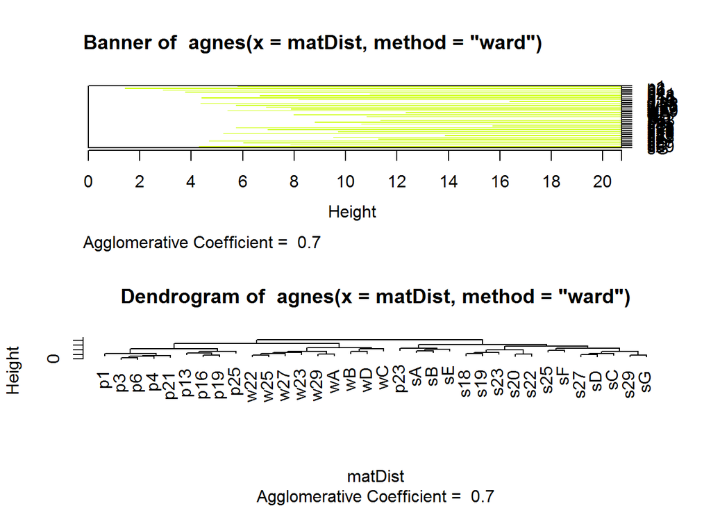

```r
par(mfrow=c(2,1))
plot(lstOfHClust_Ward$Euclidean)
```

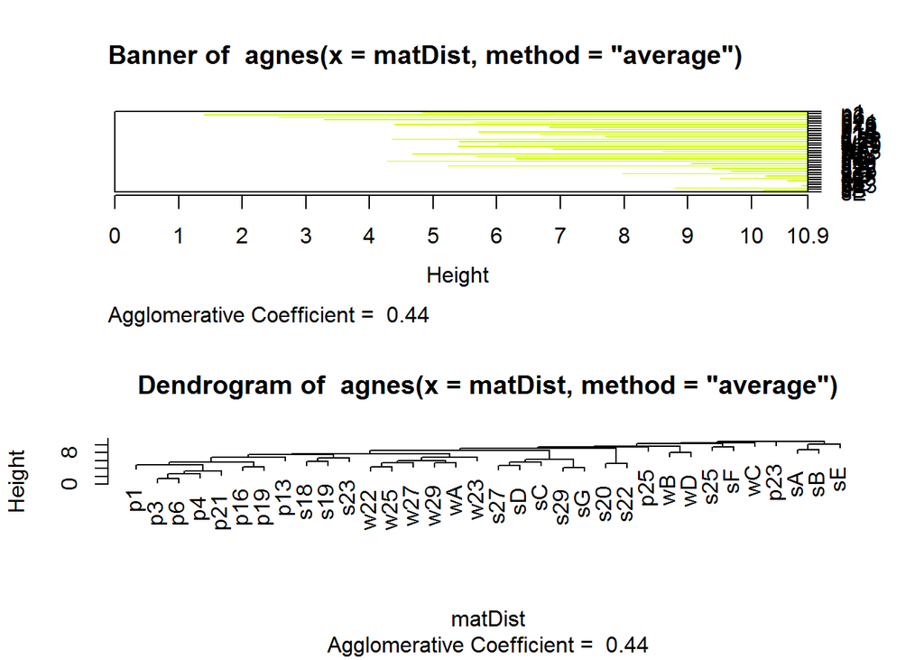

```r
plot(lstOfHClust_Ave$Euclidean)
```

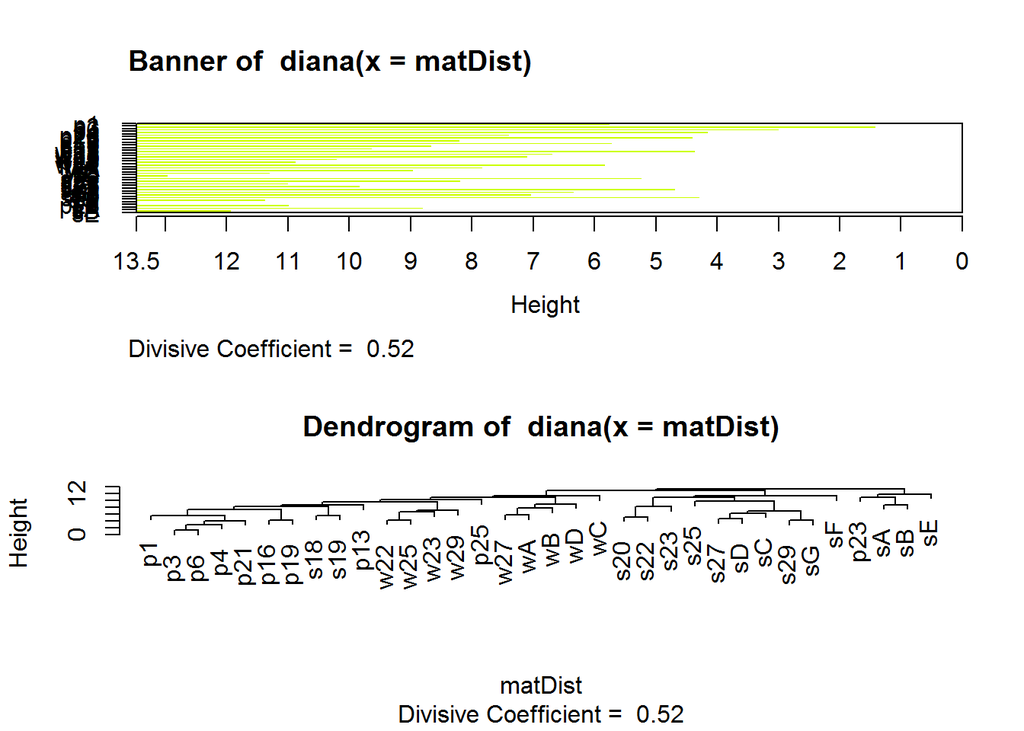

```r
plot(lstOfDClust$Euclidean)
```

*Manhattan Distance Method*

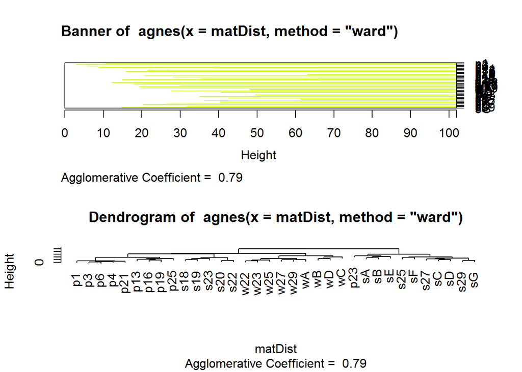

```r
par(mfrow=c(2,1))
plot(lstOfHClust_Ward$Manhattan)
```

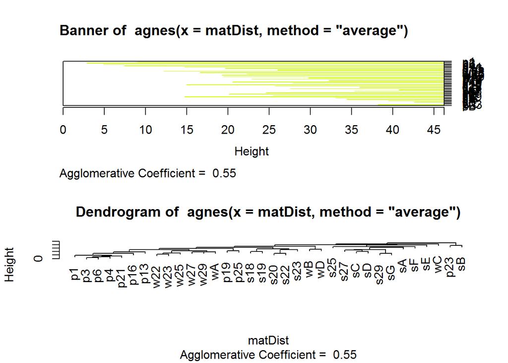

```r
plot(lstOfHClust_Ave$Manhattan)
```

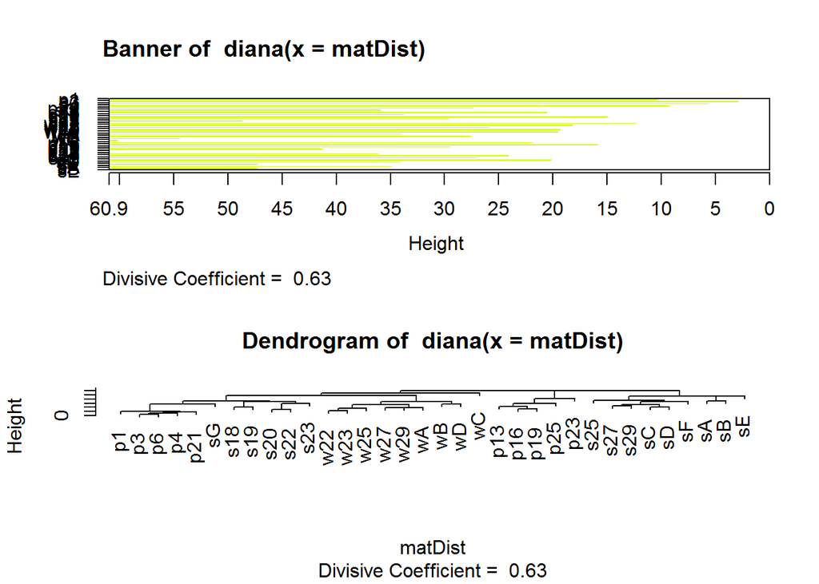

```r
plot(lstOfDClust$Manhattan)
```

*Canberra Distance Method*

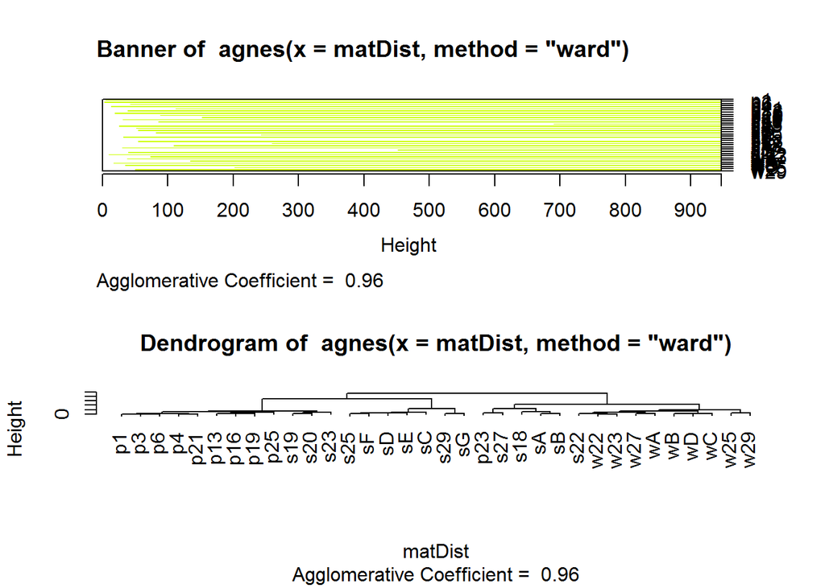

```r
par(mfrow=c(2,1))
plot(lstOfHClust_Ward$Canberra)
```

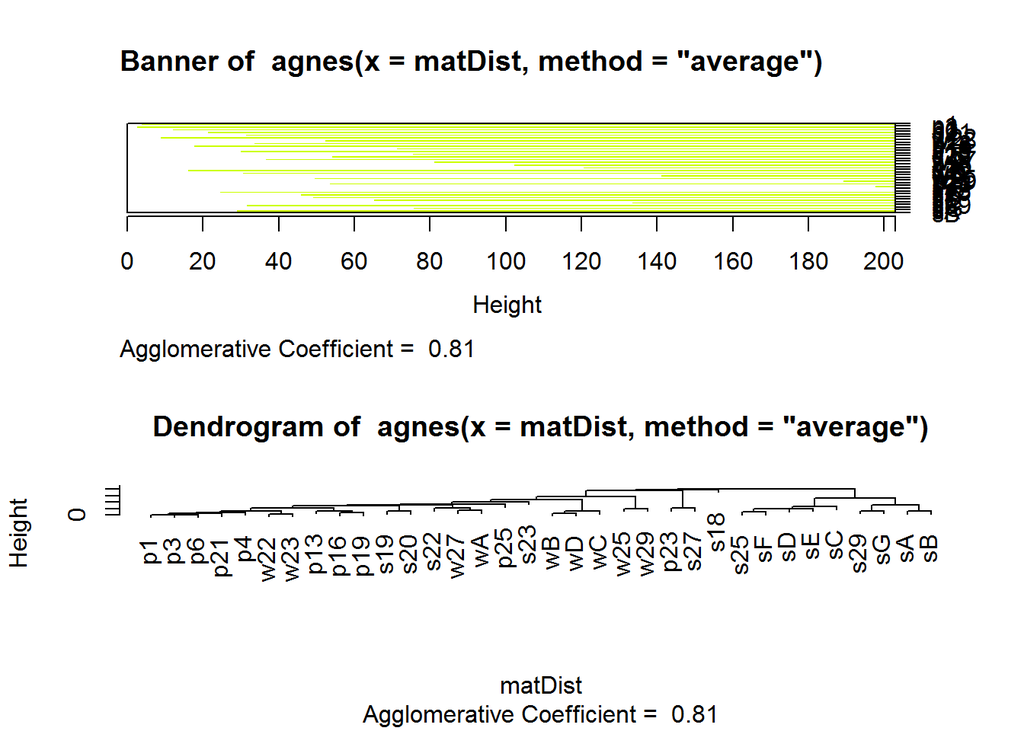

```r
plot(lstOfHClust_Ave$Canberra)
```

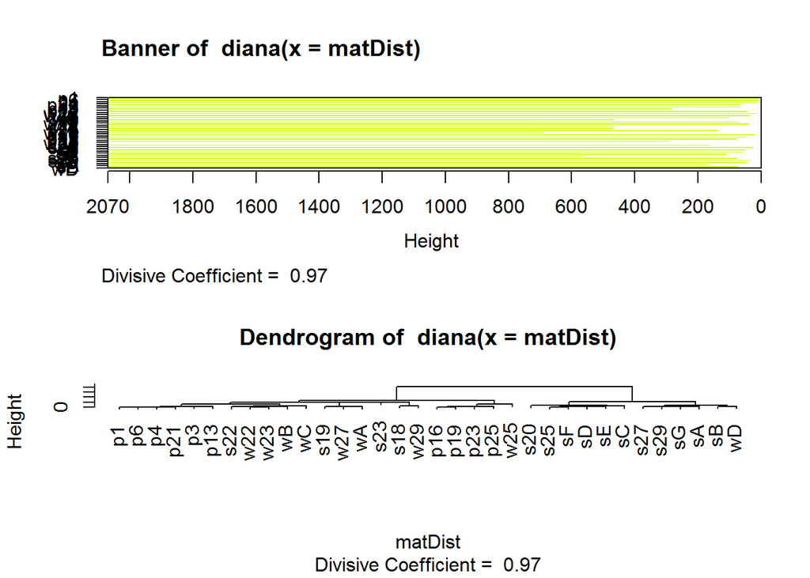

```r
plot(lstOfDClust$Canberra)
```

### Cluster around 5 mediods (clusters)

*Chord Distance Method*

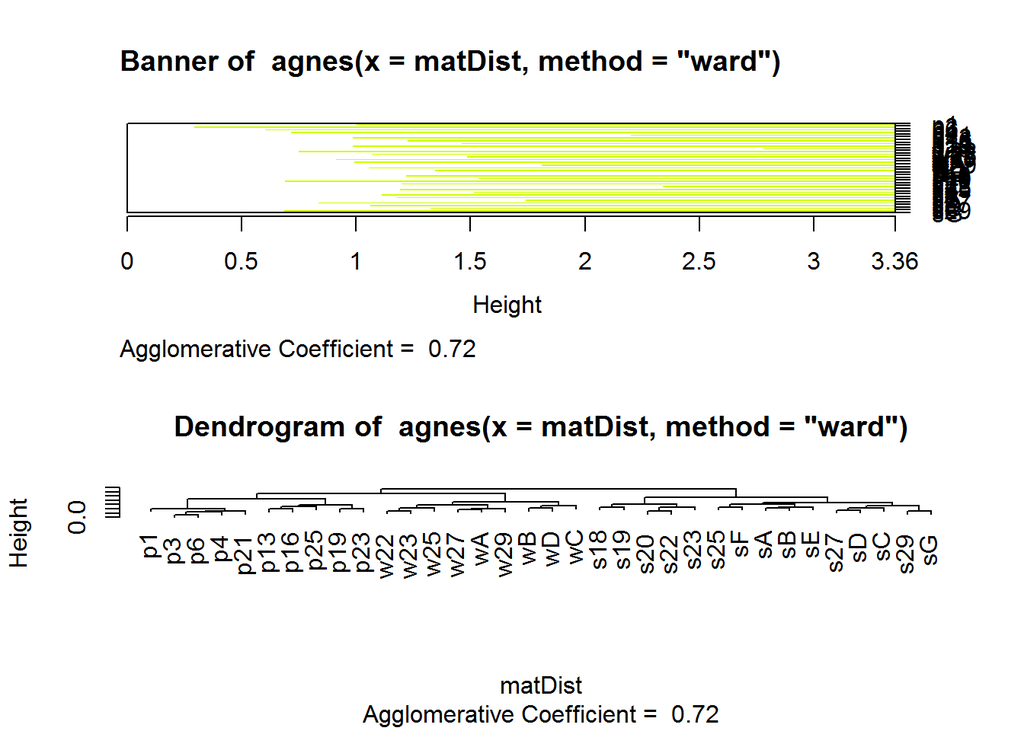

```r
par(mfrow=c(2,1))
plot(lstOfHClust_Ward$Chord)
```

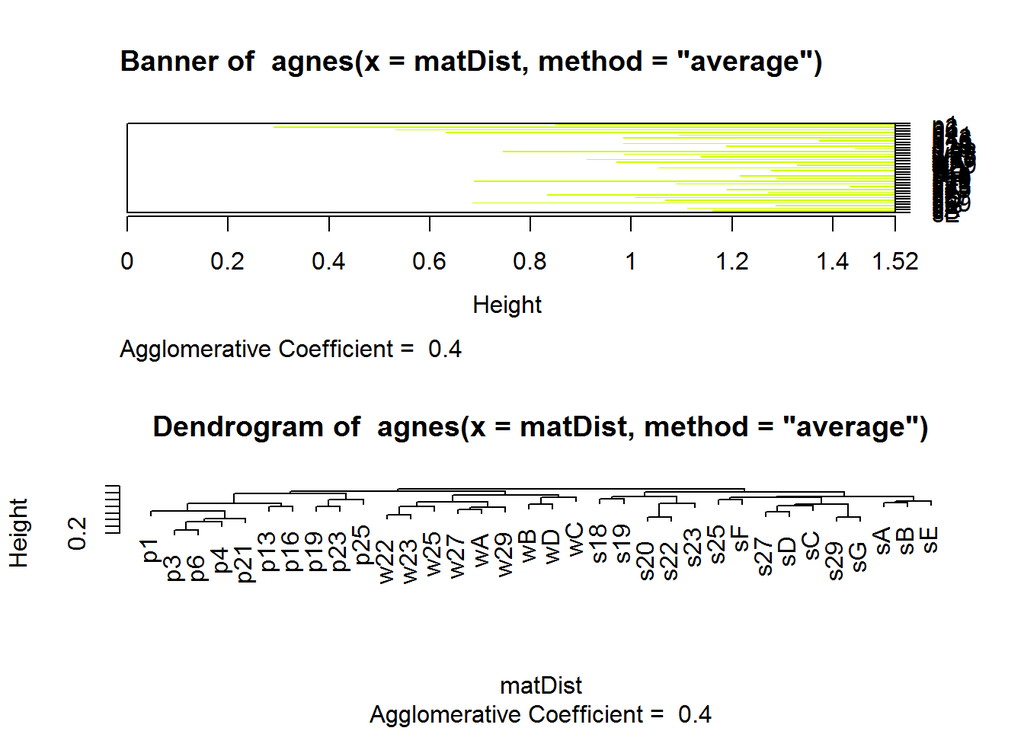

```r
plot(lstOfHClust_Ave$Chord)
```

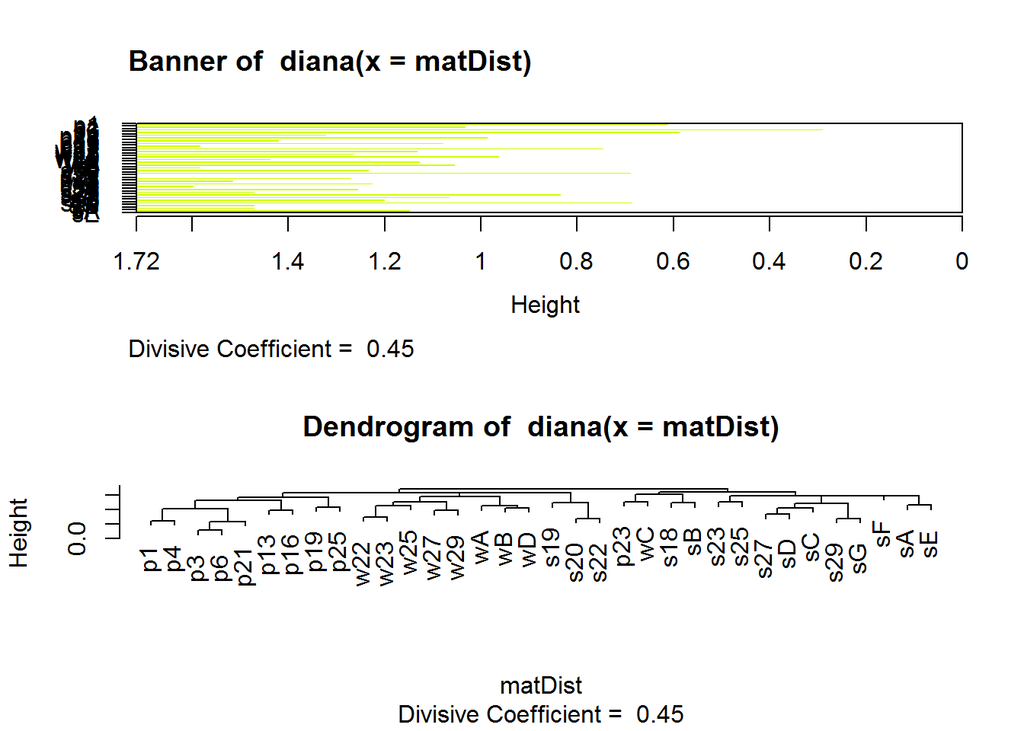

```r
plot(lstOfDClust$Chord)
```

### Cluster around 12 mediods (clusters)

*Maximum Distance Method*

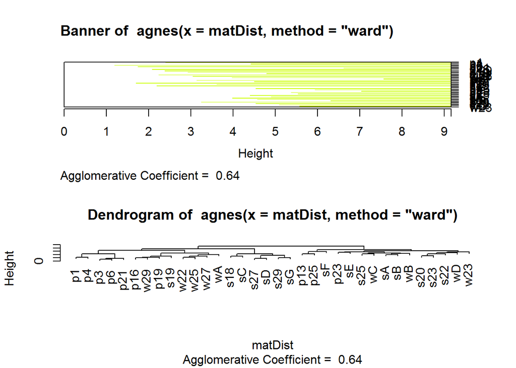

```r
par(mfrow=c(2,1))
plot(lstOfHClust_Ward$Maximum)
```

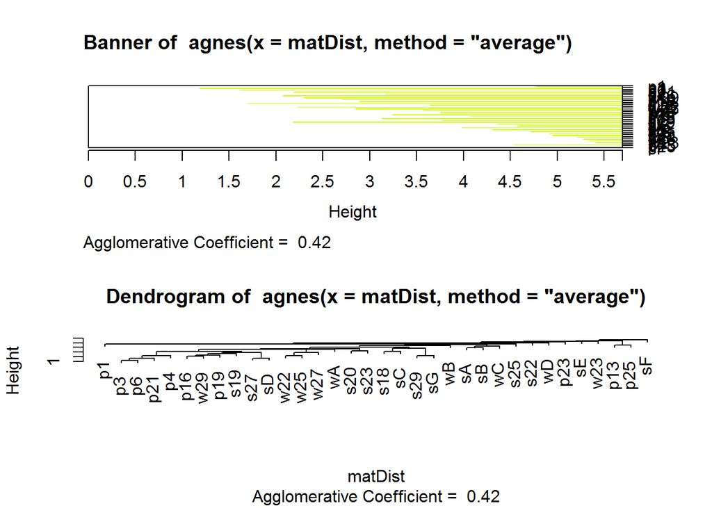

```r
plot(lstOfHClust_Ave$Maximum)
```

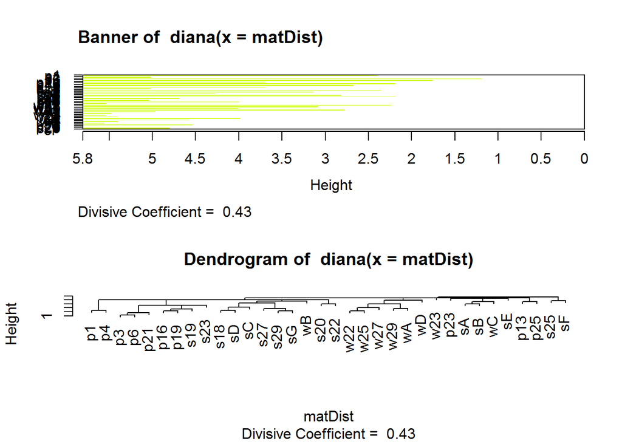

```r
plot(lstOfDClust$Maximum)
```

### cophenetic correlation

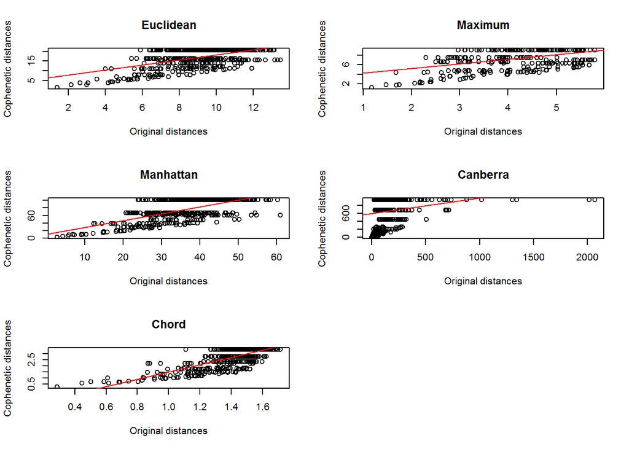

```r
par(mfrow=c(3,2))
for(idx in lstOfDist$MethodType){
    matDist <- lstOfDist[[idx]]
    fit <- lm(
        as.vector(cophenetic(lstOfHClust_Ward[[idx]]))~
        as.vector(matDist))

    plot(
        matDist,
        cophenetic(lstOfHClust_Ward[[idx]]),
        xlab="Original distances",
        ylab="Cophenetic distances",
        main=idx)

    abline(fit, col="red")
}
par(mfrow=c(1,1))
```

### aggolmerative coefficient & cophenetic correlation

```r
resCompare <- data.frame(
    Method = c(
        "Euclidean", "Manhattan",
        "Canberra", "Chord", "Maximum"),
    k = c(2, 2, 2, 5, 12))

temp <- apply(resCompare, 1, function(x){
    # set parameters
    idx = x[1]
    k   = x[2]
    matDist <- lstOfDist[[idx]]

    # Aggolmerative coefficient
    res  = c()
    temp = coef(lstOfHClust_Ward[[idx]])
    res  = c(res, temp)

    temp = coef(lstOfHClust_Ave[[idx]])
    res  = c(res, temp)

    temp = coef(lstOfDClust[[idx]])
    res  = c(res, temp)

    # cophenetic correlation
    temp = cor(matDist, cophenetic(lstOfHClust_Ward[[idx]]))
    res  = c(res, temp)

    temp = cor(matDist, cophenetic(lstOfHClust_Ave[[idx]]))
    res  = c(res, temp)

    temp = cor(matDist, cophenetic(lstOfDClust[[idx]]))
    res  = c(res, temp)

    # return the result
    names(res) <- c(
        paste("AggoCoef", c("Ward", "Ave", "Diana")),
        paste("CophCorr", c("Ward", "Ave", "Diana")))
    return(res)
})

# Combine results
resCompare <- cbind(resCompare, t(as.data.frame(temp)))
print(resCompare)
```

```
##       Method  k AggoCoef Ward AggoCoef Ave AggoCoef Diana CophCorr Ward
## V1 Euclidean  2     0.7037324    0.4428623      0.5168047     0.5460465
## V2 Manhattan  2     0.7879902    0.5468363      0.6299042     0.6675823
## V3  Canberra  2     0.9627595    0.8129272      0.9659171     0.2080042
## V4     Chord  5     0.7220023    0.4009729      0.4475533     0.7745830
## V5   Maximum 12     0.6390824    0.4156563      0.4287262     0.4935743
##    CophCorr Ave CophCorr Diana
## V1    0.8469193      0.7366751
## V2    0.8202007      0.6412135
## V3    0.3298599      0.2635106
## V4    0.8685233      0.8347626
## V5    0.9064249      0.6352085
```

### Silhouette Score

Silhouette Score of cut hierarchical tree. Here I use Ward method with Euclidean distance matrix

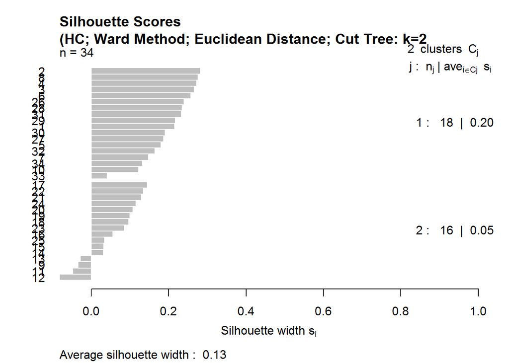

```r
plot(silhouette(
    cutree(lstOfHClust_Ward$Euclidean,2),
    lstOfDist$Euclidean),
    main="Silhouette Scores\n(HC; Ward Method; Euclidean Distance; Cut Tree: k=2")
```

### Description of Clusters

boxplot of different clusters

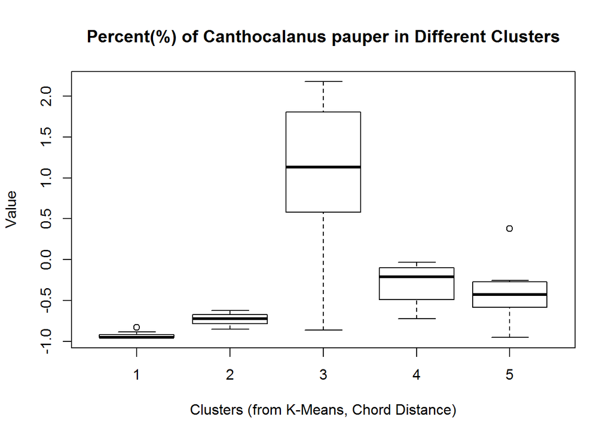

```r
dat <- datCPOD$CompDmtScale
#which.max(apply(dat, 2, mad))
#=> Canthocalanus pauper

# plot
boxplot(
    dat[,"Canthocalanus pauper"] ~ lstOfKClust$Chord$clustering,
    xlab="Clusters (from K-Means, Chord Distance)",
    ylab="Value",
    main="Percent(%) of Canthocalanus pauper in Different Clusters")
```

Kruskal-Wallis test

```r
kruskal.test(
    dat[,"Canthocalanus pauper"] ~ lstOfKClust$Chord$clustering
)
```

```
##
##  Kruskal-Wallis rank sum test
##
## data:  dat[, "Canthocalanus pauper"] by lstOfKClust$Chord$clustering
## Kruskal-Wallis chi-squared = 24.09, df = 4, p-value = 7.662e-05
```